# Running PaCMAP on a Seurat Object

Compiled: Nov 20, 2024

This vignette demonstrates how to run PaCMAP, a dimensionality reduction method that can be used for providing robust and trustworthy visualization, on a Seurat object. If you use our work, please cite both papers:

> *Understanding How Dimension Reduction Tools Work: An Empirical Approach to Deciphering t-SNE, UMAP, TriMap, and PaCMAP for Data Visualization*

> Yingfan Wang, Haiyang Huang, Cynthia Rudin & Yaron Shaposhnik

> Journal of Machine Learning Research, 2021

> doi: https://doi.org/10.48550/arXiv.2012.04456

> *Towards a comprehensive evaluation of dimension reduction methods for transcriptomic data visualization*

> Haiyang Huang, Yingfan Wang, Cynthia Rudin and Edward P. Browne

> Communications biology, 2022

> doi: https://doi.org/10.1038/s42003-022-03628-x

> GitHub: https://github.com/YingfanWang/PaCMAP

Prerequisites to install:

- [Seurat](https://satijalab.org/seurat/install)
- [SeuratWrappers](https://github.com/satijalab/seurat-wrappers)
- [SeuratData](https://github.com/satijalab/seurat-data)
- [Reticulate](https://rstudio.github.io/reticulate/)

In addition to R packages, PaCMAP relies on Python to deliver high performance. To streamline the installation process and make environment management easier, we strongly recommend you to use anaconda(https://www.anaconda.com/download) or miniconda(https://docs.anaconda.com/miniconda/miniconda-install/) for managing Python environments. Below, we provide step-by-step instructions on how to properly install PaCMAP **after** you have installed one of these tools.

Create a conda environment with PaCMAP installed:

```bash
conda create -n "pacmap" python=3.12  # Install in the environment called "pacmap"
conda activate pacmap
conda install -y conda-forge::pacmap
```

To run PaCMAP, you need to connect your R console to the corresponding conda environment. If your Conda/Miniconda installation is located in a non-default directory, you might set up the conda variable as `/path/to/your/conda`. This ensures the correct environment is used during the installation.

```r
reticulate::use_condaenv(condaenv = "pacmap", conda = "auto")
```

```r
library(Seurat)
library(SeuratData)
library(SeuratWrappers)
```

### PaCMAP on PBMC3k

To learn more about this dataset, type `?pbmc3k`

```r
InstallData("pbmc3k")
pbmc3k.final <- LoadData("pbmc3k",type="pbmc3k.final")

# Initial processing to select variable features
pbmc3k.final <- UpdateSeuratObject(pbmc3k.final)
pbmc3k.final <- FindVariableFeatures(pbmc3k.final)

# run PaCMAP on Seurat object.
pbmc3k.final <- RunPaCMAP(object = pbmc3k.final, features=VariableFeatures(pbmc3k.final))
```

```
## Applied PCA, the dimensionality becomes 100
## PaCMAP(n_neighbors=10, n_MN=5, n_FP=20, distance=euclidean, lr=1.0, n_iters=(100, 100, 450), apply_pca=True, opt_method='adam', verbose=True, intermediate=False, seed=11)
## Finding pairs
## Found nearest neighbor
## Calculated sigma
## Found scaled dist
## Pairs sampled successfully.
## ((26380, 2), (13190, 2), (52760, 2))
## Initial Loss: 32494.857421875
## Iteration:   10, Loss: 25802.580078
## Iteration:   20, Loss: 21603.363281
## Iteration:   30, Loss: 19970.650391
## Iteration:   40, Loss: 18992.988281
## Iteration:   50, Loss: 18181.544922
## Iteration:   60, Loss: 17354.800781
## Iteration:   70, Loss: 16440.773438
## Iteration:   80, Loss: 15367.431641
## Iteration:   90, Loss: 14006.279297
## Iteration:  100, Loss: 11969.539062
## Iteration:  110, Loss: 14622.074219
## Iteration:  120, Loss: 14481.925781
## Iteration:  130, Loss: 14432.553711
## Iteration:  140, Loss: 14414.109375
## Iteration:  150, Loss: 14406.267578
## Iteration:  160, Loss: 14402.332031
## Iteration:  170, Loss: 14400.175781
## Iteration:  180, Loss: 14398.969727
## Iteration:  190, Loss: 14398.415039
## Iteration:  200, Loss: 14398.177734
## Iteration:  210, Loss: 7290.769531
## Iteration:  220, Loss: 7165.277344
## Iteration:  230, Loss: 7109.806641
## Iteration:  240, Loss: 7076.959961
## Iteration:  250, Loss: 7059.577148
## Iteration:  260, Loss: 7048.008301
## Iteration:  270, Loss: 7038.852539
## Iteration:  280, Loss: 7031.291504
## Iteration:  290, Loss: 7024.563477
## Iteration:  300, Loss: 7018.940430
## Iteration:  310, Loss: 7013.954102
```

[output cut: 20 more lines]

```
## Iteration:  520, Loss: 6965.000977
## Iteration:  530, Loss: 6963.808105
## Iteration:  540, Loss: 6962.668945
## Iteration:  550, Loss: 6961.575195
## Iteration:  560, Loss: 6960.505371
## Iteration:  570, Loss: 6959.466309
## Iteration:  580, Loss: 6958.451172
## Iteration:  590, Loss: 6957.499023
## Iteration:  600, Loss: 6956.579102
## Iteration:  610, Loss: 6955.684570
## Iteration:  620, Loss: 6954.833984
## Iteration:  630, Loss: 6954.013672
## Iteration:  640, Loss: 6953.199219
## Iteration:  650, Loss: 6952.405762
## Elapsed time: 1.35s
```

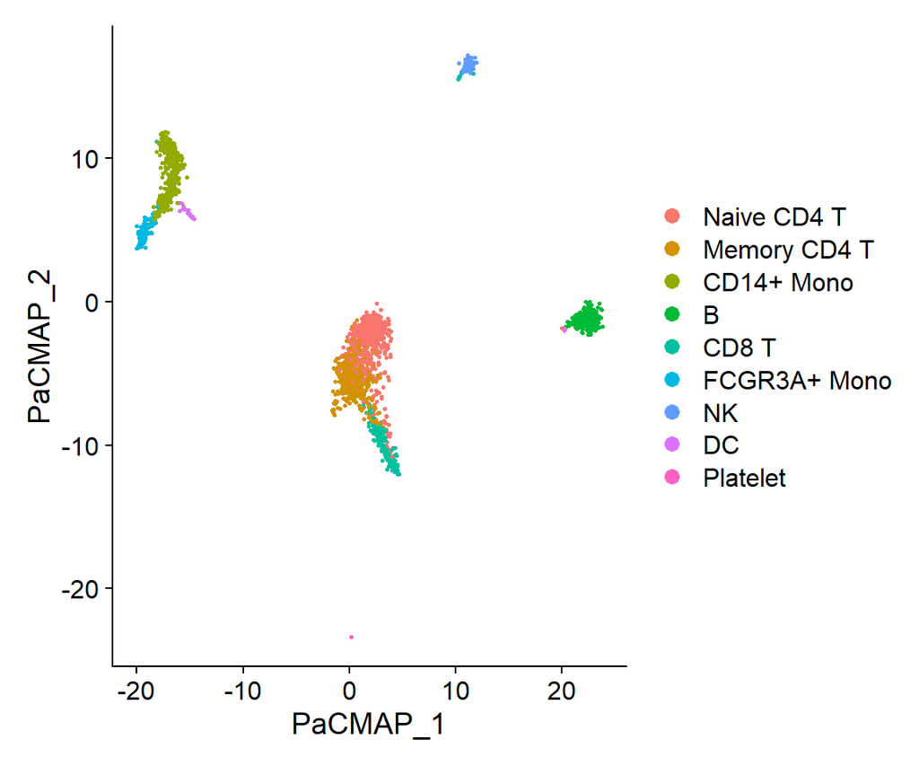

```r
# visualize markers
features.plot <- c('CD3D', 'MS4A1', 'CD8A', 'GZMK', 'GZMB', 'FCGR3A')
DimPlot(object=pbmc3k.final,reduction="pacmap")
```

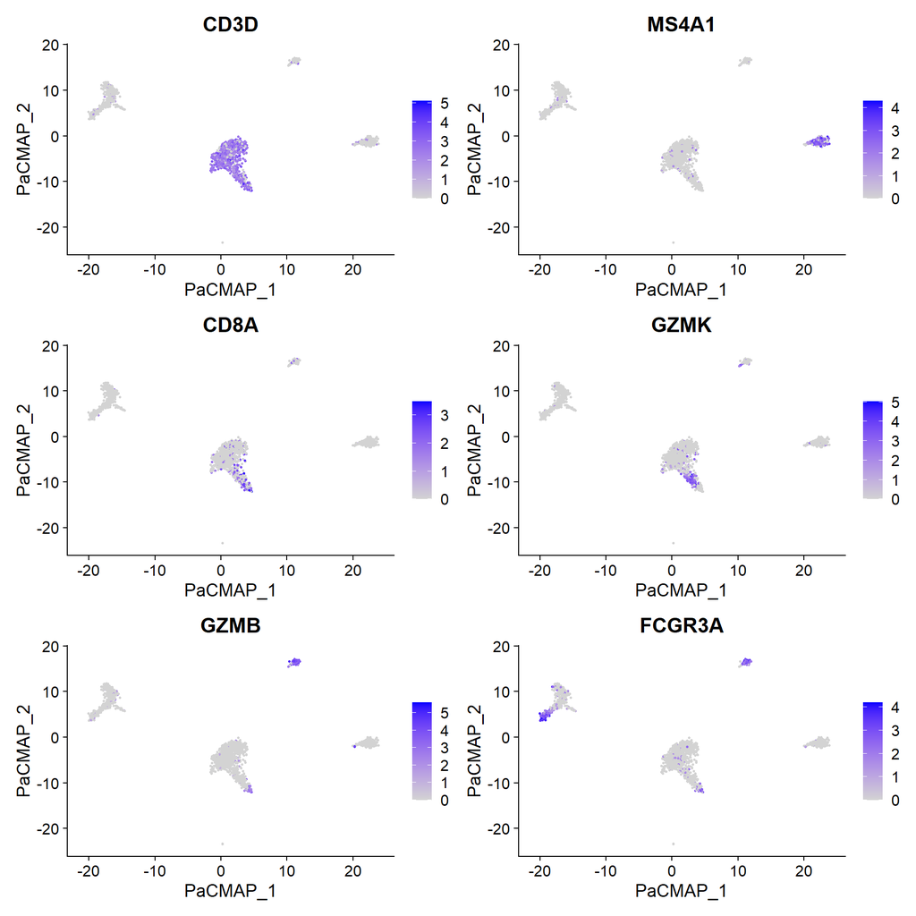

```r
pbmc3k.final <- NormalizeData(pbmc3k.final, verbose = FALSE)
FeaturePlot(pbmc3k.final, features.plot, ncol = 2, reduction="pacmap")
```

You can also specify dims of your original dataset for running PaCMAP

```r
# run PaCMAP on Seurat object.
pbmc3k.final <- RunPaCMAP(object = pbmc3k.final, dims=2:5)
```

```
## X is normalized
## PaCMAP(n_neighbors=10, n_MN=5, n_FP=20, distance=euclidean, lr=1.0, n_iters=(100, 100, 450), apply_pca=True, opt_method='adam', verbose=True, intermediate=False, seed=11)
## Finding pairs
## Found nearest neighbor
## Calculated sigma
## Found scaled dist
## Pairs sampled successfully.
## ((26380, 2), (13190, 2), (52760, 2))
## Initial Loss: 32494.857421875
## Iteration:   10, Loss: 25271.613281
## Iteration:   20, Loss: 21621.359375
## Iteration:   30, Loss: 19508.974609
## Iteration:   40, Loss: 18132.957031
## Iteration:   50, Loss: 17056.433594
## Iteration:   60, Loss: 16103.467773
## Iteration:   70, Loss: 15062.871094
## Iteration:   80, Loss: 13834.863281
## Iteration:   90, Loss: 12237.625000
## Iteration:  100, Loss: 9772.316406
## Iteration:  110, Loss: 12138.644531
## Iteration:  120, Loss: 12073.764648
## Iteration:  130, Loss: 12035.579102
## Iteration:  140, Loss: 12024.872070
## Iteration:  150, Loss: 12020.273438
## Iteration:  160, Loss: 12017.477539
## Iteration:  170, Loss: 12016.250000
## Iteration:  180, Loss: 12015.735352
## Iteration:  190, Loss: 12015.256836
## Iteration:  200, Loss: 12014.985352
## Iteration:  210, Loss: 5415.976562
## Iteration:  220, Loss: 5314.317383
## Iteration:  230, Loss: 5279.950195
## Iteration:  240, Loss: 5264.435059
## Iteration:  250, Loss: 5255.370605
## Iteration:  260, Loss: 5248.233398
## Iteration:  270, Loss: 5243.097168
## Iteration:  280, Loss: 5239.238281
## Iteration:  290, Loss: 5236.099609
## Iteration:  300, Loss: 5233.452637
## Iteration:  310, Loss: 5231.186523
```

[output cut: 20 more lines]

```
## Iteration:  520, Loss: 5210.794434
## Iteration:  530, Loss: 5210.372559
## Iteration:  540, Loss: 5209.990723
## Iteration:  550, Loss: 5209.612305
## Iteration:  560, Loss: 5209.245117
## Iteration:  570, Loss: 5208.909180
## Iteration:  580, Loss: 5208.585938
## Iteration:  590, Loss: 5208.267578
## Iteration:  600, Loss: 5207.946777
## Iteration:  610, Loss: 5207.659668
## Iteration:  620, Loss: 5207.363281
## Iteration:  630, Loss: 5207.092285
## Iteration:  640, Loss: 5206.832520
## Iteration:  650, Loss: 5206.579102
## Elapsed time: 1.53s
```

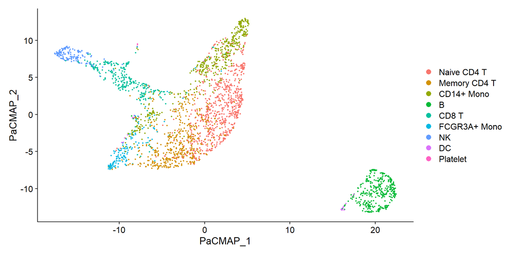

```r
# visualize markers
features.plot <- c('CD3D', 'MS4A1', 'CD8A', 'GZMK', 'GZMB', 'FCGR3A')
DimPlot(object=pbmc3k.final,reduction="pacmap")
```